# Substitution Analysis

Sean Trott

2023-06-05

# Introduction

This file contains analyses that ask whether GPT-4’s ratings can be **substituted** for human ratings without changing the qualitative inferences of that analysis.

# Dataset 1: Iconicity

Here, we replicate the key analyses from Winter et al. (2023).

## Load and merge iconicity data

```r
df_gpt = read_csv("../../data/processed/iconicity/iconicity_gpt-4.csv")
nrow(df_gpt)
```

```
## [1] 14772
```

```r
df_human = read_csv("../../data/raw/iconicity/iconicity.csv")
nrow(df_human)
```

```
## [1] 14776
```

```r
df_merged = df_human %>%
  inner_join(df_gpt)
nrow(df_merged)
```

```
## [1] 14772
```

## Load and merge relevant covariates

These datasets contain information to replicate one of the key analyses from Winter et al. (2023).

```r
df_conc = read_csv("../../data/lexical_statistics/winter2023/brysbaert_2014_concreteness.csv") %>%
  mutate(word = Word)
nrow(df_conc)
```

```
## [1] 39954
```

```r
df_humor = read_csv("../../data/lexical_statistics/winter2023/engelthaler_hills_2018_humor.csv") %>%
  select(-n) %>%
  mutate(humor = mean)
nrow(df_humor)
```

```
## [1] 4997
```

```r
df_ser = read_csv("../../data/lexical_statistics/winter2023/juhasz_yap_2013_SER.csv") %>%
  mutate(word = Word)
nrow(df_ser)
```

```
## [1] 5857
```

```r
df_aoa = read_csv("../../data/lexical_statistics/winter2023/kuperman_2012_AOA.csv") %>%
  mutate(word = Word,
         AoA = Rating.Mean)
nrow(df_aoa)
```

```
## [1] 31124
```

```r
df_arc = read_csv("../../data/lexical_statistics/winter2023/shaoul_westbury_2010_ARC.csv") %>%
  mutate(word = tolower(WORD))
nrow(df_arc)
```

```
## [1] 57153
```

```r
df_subtlex = read_csv("../../data/lexical_statistics/winter2023/brysbaert_2012_SUBTLEX_POS.csv") %>%
  mutate(word = Word)
nrow(df_subtlex)
```

```
## [1] 74286
```

```r
df_ding = read_csv("../../data/lexical_statistics/winter2023/dingemanse_thompson_2020.csv")
nrow(df_ding)
```

```
## [1] 67967
```

## Analysis 1: Replicating Winter et al. (2023)

First, merge all the datasets together.

```r
df_merged_subs = df_merged %>%
  inner_join(df_conc, by = "word") %>%
  inner_join(df_ser, by = "word") %>%
  inner_join(df_humor, by = "word") %>%
  inner_join(df_aoa, by = "word") %>%
  inner_join(df_subtlex, by = "word") %>%
  inner_join(df_arc, by = "word") %>%
  inner_join(df_ding, by = "word")

nrow(df_merged_subs)
```

```
## [1] 3223
```

```r
### Standardize
df_merged_subs = df_merged_subs %>%
  mutate(ARC_z = scale(ARC),
         SER_z = scale(SER),
         CONC_z = scale(Conc.M),
         Humor_z = scale(humor),
         AoA_z = scale(AoA),
         Lg10WF_z = scale(Lg10WF),
         LgLetter_z = scale(logletterfreq))
```

Then, replicate the main Winter et al. (2023) analysis and redo with GPT-4 ratings.

```r
mod_full = lm(data = df_merged_subs,
              rating ~ ARC_z * SER_z +
                CONC_z + Humor_z + AoA_z + Lg10WF_z + LgLetter_z + POS)

df_model = broom::tidy(mod_full) %>%
  mutate(source = "Human")

df_model
```

```
## # A tibble: 16 × 6
##    term            estimate std.error statistic  p.value source
##    <chr>              <dbl>     <dbl>     <dbl>    <dbl> <chr>
##  1 (Intercept)       4.02      0.0594    67.7   0        Human
##  2 ARC_z            -0.159     0.0221    -7.20  7.21e-13 Human
##  3 SER_z             0.101     0.0156     6.47  1.10e-10 Human
##  4 CONC_z           -0.0942    0.0174    -5.40  7.15e- 8 Human
##  5 Humor_z           0.126     0.0168     7.49  8.58e-14 Human
##  6 AoA_z            -0.222     0.0209   -10.6   6.77e-26 Human
##  7 Lg10WF_z         -0.101     0.0250    -4.03  5.63e- 5 Human
##  8 LgLetter_z       -0.155     0.0148   -10.5   2.34e-25 Human
##  9 POSAdverb        -0.316     0.409     -0.772 4.40e- 1 Human
## 10 POSInterjection   1.67      0.808      2.06  3.95e- 2 Human
## 11 POSName          -0.432     0.211     -2.05  4.06e- 2 Human
## 12 POSNoun          -0.188     0.0621    -3.03  2.44e- 3 Human
## 13 POSNumber         0.0606    0.264      0.230 8.18e- 1 Human
## 14 POSPreposition   -1.17      0.809     -1.44  1.49e- 1 Human
## 15 POSVerb           0.326     0.0705     4.63  3.85e- 6 Human
## 16 ARC_z:SER_z       0.0199    0.0144     1.39  1.65e- 1 Human
```

```r
### GPT-4 analysis
mod_full_gpt = lm(data = df_merged_subs,
              gpt4_rating ~ ARC_z * SER_z +
                CONC_z + Humor_z + AoA_z + Lg10WF_z + LgLetter_z + POS)

df_model_gpt = broom::tidy(mod_full_gpt) %>%
  mutate(source = "GPT-4")

df_model_gpt
```

```
## # A tibble: 16 × 6
##    term            estimate std.error statistic  p.value source
##    <chr>              <dbl>     <dbl>     <dbl>    <dbl> <chr>
##  1 (Intercept)       3.74      0.0613   61.1    0        GPT-4
##  2 ARC_z            -0.204     0.0228   -8.95   5.99e-19 GPT-4
##  3 SER_z             0.167     0.0161   10.3    1.02e-24 GPT-4
##  4 CONC_z           -0.0585    0.0180   -3.25   1.18e- 3 GPT-4
##  5 Humor_z           0.0900    0.0173    5.20   2.16e- 7 GPT-4
##  6 AoA_z            -0.362     0.0215  -16.8    1.02e-60 GPT-4
##  7 Lg10WF_z         -0.253     0.0258   -9.82   1.97e-22 GPT-4
##  8 LgLetter_z       -0.143     0.0152   -9.38   1.17e-20 GPT-4
##  9 POSAdverb         0.418     0.422     0.991  3.22e- 1 GPT-4
## 10 POSInterjection   1.58      0.834     1.90   5.80e- 2 GPT-4
## 11 POSName          -0.291     0.218    -1.34   1.82e- 1 GPT-4
## 12 POSNoun          -0.236     0.0641   -3.68   2.41e- 4 GPT-4
## 13 POSNumber        -0.973     0.272    -3.58   3.53e- 4 GPT-4
## 14 POSPreposition    0.0816    0.835     0.0977 9.22e- 1 GPT-4
## 15 POSVerb           0.526     0.0728    7.23   6.15e-13 GPT-4
## 16 ARC_z:SER_z       0.0157    0.0148    1.06   2.89e- 1 GPT-4
```

Directly compare coefficients.

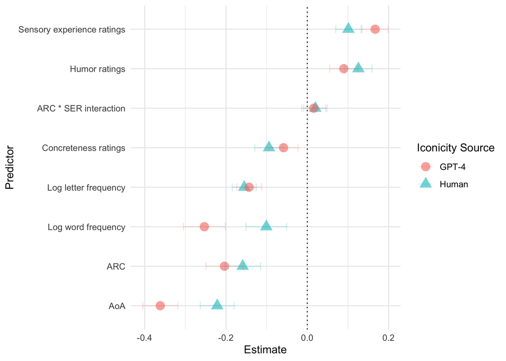

```r
df_both = df_model %>%
  bind_rows(df_model_gpt)

df_both = df_both %>%
  filter(term != "(Intercept)") %>%
  filter(!grepl("POS", term)) %>%
  mutate(term = case_when(
    term == "Humor_z" ~ "Humor ratings",
    term == "SER_z" ~ "Sensory experience ratings",
    term == "ARC_z:SER_z" ~ "ARC * SER interaction",
    term == "CONC_z" ~ "Concreteness ratings",
    term == "Lg10WF_z" ~ "Log word frequency",
    term == "LgLetter_z" ~ "Log letter frequency",
    term == "ARC_z" ~ "ARC",
    term == "AoA_z" ~ "AoA"
    ))

df_both %>%
  ggplot(aes(x = reorder(term, estimate),
             y = estimate,
             color = source,
             shape = source)) +
  geom_point(size = 4, alpha = .6) +
  coord_flip() +
  geom_hline(yintercept = 0, linetype = "dotted") +
  geom_errorbar(aes(ymin = estimate - 2*std.error,
                    ymax = estimate + 2*std.error),
                alpha = .2,
                width=.2) +
                # position=position_dodge(.9)) +
  labs(x = "Predictor",
       y = "Estimate",
       color = "Iconicity Source",
       shape = "Iconicity Source") +
  theme_minimal()
```

### Quantifying differences

We can also quantify the differences more directly.

```r
df_both_wide = df_both %>%
  select(term, estimate, std.error, source) %>%
  pivot_wider(names_from = "source", values_from = c(estimate, std.error))

### Now calculate differences and scale by std.error
df_both_wide = df_both_wide %>%
  mutate(diff = estimate_Human - `estimate_GPT-4`,
         se_diff = sqrt(std.error_Human**2+ `std.error_GPT-4`**2),
         diff_scaled = diff / se_diff,
         diff_abs = abs(diff))

df_both_wide %>%
  arrange(desc(diff_abs)) %>%
  select(term, diff)
```

```
## # A tibble: 8 × 2
##   term                           diff
##   <chr>                         <dbl>
## 1 Log word frequency          0.152
## 2 AoA                         0.140
## 3 Sensory experience ratings -0.0658
## 4 ARC                         0.0447
## 5 Humor ratings               0.0358
## 6 Concreteness ratings       -0.0358
## 7 Log letter frequency       -0.0120
## 8 ARC * SER interaction       0.00419
```

```r
### Now calculate t-test
n = nrow(df_merged_subs)
p = length(coefficients(mod_full)) - 1
df = n - p

### Calculate p-values
df_both_wide = df_both_wide %>%
  mutate(p = 2 * pt(abs(diff_scaled), df = df, lower.tail = FALSE)) %>%
  mutate(significant = p < .05)

df_both_wide %>%
  arrange(desc(diff_abs)) %>%
  filter(significant == TRUE) %>%
  select(term, diff_abs, diff_scaled, p)
```

```
## # A tibble: 3 × 4
##   term                       diff_abs diff_scaled          p
##   <chr>                         <dbl>       <dbl>      <dbl>
## 1 Log word frequency           0.152         4.24 0.0000227
## 2 AoA                          0.140         4.67 0.00000312
## 3 Sensory experience ratings   0.0658       -2.93 0.00345
```

# Dataset 2: Relatedness (and sensorimotor distance)

Here, we replicate the analysis predicting human relatedness judgments (Trott & Bergen, 2022) using **sensorimotor distance**. We first use a measure of sensorimotor distance from human-generated contextualized norms, then a measure of sensorimotor distance from LLM-generated contextualized norms.

## Load data

```r
df_rawc_with_sm = read_csv("../../data/lexical_statistics/relatedness/rawc_with_sm.csv")
nrow(df_rawc_with_sm)
```

```
## [1] 672
```

```r
### Descriptive stats
cor.test(df_rawc_with_sm$sm_gpt, df_rawc_with_sm$sm_human, method = "spearman")
```

```
##
##  Spearman's rank correlation rho
##
## data:  df_rawc_with_sm$sm_gpt and df_rawc_with_sm$sm_human
## S = 21127522, p-value < 2.2e-16
## alternative hypothesis: true rho is not equal to 0
## sample estimates:
##       rho
## 0.5822726
```

## Analysis 1: Predicting human relatedness judgments

First, we build the models:

```r
mod_human = lm(data = df_rawc_with_sm,
               mean_relatedness ~ sm_human +
                 distance_bert +
                 same * ambiguity_type)

df_model_human = broom::tidy(mod_human) %>%
  mutate(source = "Human")

df_model_human
```

```
## # A tibble: 6 × 6
##   term                            estimate std.error statistic  p.value source
##   <chr>                              <dbl>     <dbl>     <dbl>    <dbl> <chr>
## 1 (Intercept)                        1.52     0.108      14.1  1.42e-39 Human
## 2 sm_human                          -3.42     0.483      -7.08 3.63e-12 Human
## 3 distance_bert                     -1.92     0.234      -8.19 1.38e-15 Human
## 4 sameTRUE                           2.15     0.117      18.4  1.53e-61 Human
## 5 ambiguity_typePolysemy             1.14     0.0772     14.8  5.81e-43 Human
## 6 sameTRUE:ambiguity_typePolysemy   -0.764    0.130      -5.88 6.68e- 9 Human
```

```r
mod_gpt = lm(data = df_rawc_with_sm,
               mean_relatedness ~ sm_gpt +
                 distance_bert +
                 same * ambiguity_type)

df_model_gpt = broom::tidy(mod_gpt) %>%
  mutate(source = "GPT-4")

df_model_gpt
```

```
## # A tibble: 6 × 6
##   term                            estimate std.error statistic  p.value source
##   <chr>                              <dbl>     <dbl>     <dbl>    <dbl> <chr>
## 1 (Intercept)                        1.43     0.103      13.8  1.79e-38 GPT-4
## 2 sm_gpt                            -2.36     0.341      -6.91 1.13e-11 GPT-4
## 3 distance_bert                     -1.81     0.238      -7.61 9.53e-14 GPT-4
## 4 sameTRUE                           2.19     0.116      18.8  9.54e-64 GPT-4
## 5 ambiguity_typePolysemy             1.18     0.0762     15.5  2.11e-46 GPT-4
## 6 sameTRUE:ambiguity_typePolysemy   -0.778    0.130      -5.99 3.46e- 9 GPT-4
```

Overall model fits:

```r
mh = summary(mod_human)
mh$r.squared
```

```
## [1] 0.71897
```

```r
mgpt = summary(mod_gpt)
mgpt$r.squared
```

```
## [1] 0.7180277
```

Now, we directly compare coefficients.

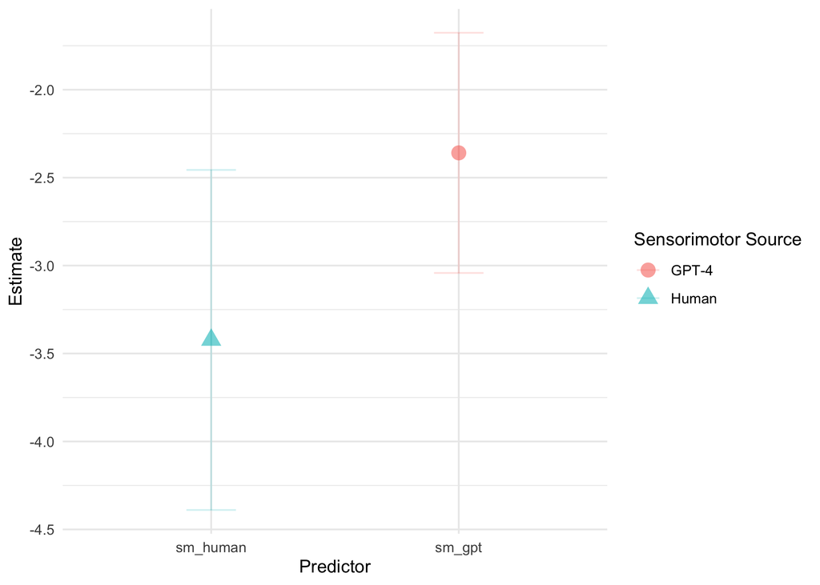

```r
df_both = df_model_human %>%
  bind_rows(df_model_gpt)

df_both = df_both %>%
  filter(term != "(Intercept)")

df_both %>%
  filter(term %in% c("sm_gpt", "sm_human")) %>%
  ggplot(aes(x = reorder(term, estimate),
             y = estimate,
             color = source,
             shape = source)) +
  geom_point(size = 4, alpha = .6) +
  # coord_flip() +
  geom_errorbar(aes(ymin = estimate - 2*std.error,
                    ymax = estimate + 2*std.error),
                alpha = .2,
                width=.2) +
                # position=position_dodge(.9)) +
  labs(x = "Predictor",
       y = "Estimate",
       color = "Sensorimotor Source",
       shape = "Sensorimotor Source") +
  theme_minimal()
```

We can also quantify the differences more directly.

```r
### first, calculate difference
diff = unname(mod_human$coefficients["sm_human"] - mod_gpt$coefficients["sm_gpt"])
abs_diff = abs(diff)
diff
```

```
## [1] -1.063556
```

```r
### next, calculate standard error of the difference
se_diff = unname(sqrt(mh$coefficients[, "Std. Error"]["sm_human"]**2 + mgpt$coefficients[, "Std. Error"]["sm_gpt"]**2))

### Z-test
n = nrow(df_rawc_with_sm)
p = length(coefficients(mod_human)) - 1
df = n - p

diff_scaled = diff / se_diff
diff_scaled
```

```
## [1] -1.797296
```

```r
p = 2 * pt(abs(diff_scaled), df = df, lower.tail = FALSE)
p
```

```
## [1] 0.07274082
```

## Analysis 2: Predicting GPT-4 relatedness judgments

First, we build the models:

```r
mod_human = lm(data = df_rawc_with_sm,
               mean_relatedness ~ sm_human +
                 distance_bert +
                 same * ambiguity_type)

df_model_human = broom::tidy(mod_human) %>%
  mutate(source = "Human")

df_model_human
```

```
## # A tibble: 6 × 6
##   term                            estimate std.error statistic  p.value source
##   <chr>                              <dbl>     <dbl>     <dbl>    <dbl> <chr>
## 1 (Intercept)                        1.52     0.108      14.1  1.42e-39 Human
## 2 sm_human                          -3.42     0.483      -7.08 3.63e-12 Human
## 3 distance_bert                     -1.92     0.234      -8.19 1.38e-15 Human
## 4 sameTRUE                           2.15     0.117      18.4  1.53e-61 Human
## 5 ambiguity_typePolysemy             1.14     0.0772     14.8  5.81e-43 Human
## 6 sameTRUE:ambiguity_typePolysemy   -0.764    0.130      -5.88 6.68e- 9 Human
```

```r
mod_gpt = lm(data = df_rawc_with_sm,
               gpt4_rating ~ sm_human +
                 distance_bert +
                 same * ambiguity_type)

df_model_gpt = broom::tidy(mod_gpt) %>%
  mutate(source = "GPT-4")

df_model_gpt
```

```
## # A tibble: 6 × 6
##   term                            estimate std.error statistic   p.value source
##   <chr>                              <dbl>     <dbl>     <dbl>     <dbl> <chr>
## 1 (Intercept)                        2.37     0.0770     30.8  3.52e-130 GPT-4
## 2 sm_human                          -2.21     0.344      -6.41 2.69e- 10 GPT-4
## 3 distance_bert                     -0.934    0.167      -5.60 3.09e-  8 GPT-4
## 4 sameTRUE                           1.43     0.0833     17.2  3.68e- 55 GPT-4
## 5 ambiguity_typePolysemy             0.427    0.0550      7.76 3.21e- 14 GPT-4
## 6 sameTRUE:ambiguity_typePolysemy   -0.538    0.0925     -5.81 9.48e-  9 GPT-4
```

Overall model fits:

```r
mh = summary(mod_human)
mh$r.squared
```

```
## [1] 0.71897
```

```r
mgpt = summary(mod_gpt)
mgpt$r.squared
```

```
## [1] 0.6355321
```

Now, we directly compare coefficients.

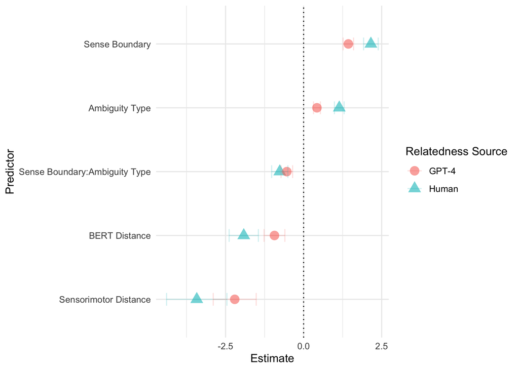

```r
df_both = df_model_human %>%
  bind_rows(df_model_gpt)

df_both = df_both %>%
  filter(term != "(Intercept)") %>%
  mutate(term = fct_recode(term,
                           "Sensorimotor Distance" = "sm_human",
                           "BERT Distance" = "distance_bert",
                           "Sense Boundary" = "sameTRUE",
                           "Ambiguity Type" = "ambiguity_typePolysemy",
                           "Sense Boundary:Ambiguity Type" = "sameTRUE:ambiguity_typePolysemy"))

df_both %>%
  ggplot(aes(x = reorder(term, estimate),
             y = estimate,
             color = source,
             shape = source)) +
  geom_point(size = 4, alpha = .6) +
  coord_flip() +
  geom_hline(yintercept = 0, linetype = "dotted") +
  geom_errorbar(aes(ymin = estimate - 2*std.error,
                    ymax = estimate + 2*std.error),
                alpha = .2,
                width=.2) +
                # position=position_dodge(.9)) +
  labs(x = "Predictor",
       y = "Estimate",
       color = "Relatedness Source",
       shape = "Relatedness Source") +
  theme_minimal()
```

### Quantifying differences

We can also quantify the differences more directly.

```r
df_both_wide = df_both %>%
  select(term, estimate, std.error, source) %>%
  pivot_wider(names_from = "source", values_from = c(estimate, std.error))

### Now calculate differences and scale by std.error
df_both_wide = df_both_wide %>%
  mutate(diff = estimate_Human - `estimate_GPT-4`,
         se_diff = sqrt(std.error_Human**2+ `std.error_GPT-4`**2),
         diff_scaled = diff / se_diff,
         diff_abs = abs(diff))

df_both_wide %>%
  arrange(desc(diff_abs)) %>%
  select(term, diff)
```

```
## # A tibble: 5 × 2
##   term                            diff
##   <fct>                          <dbl>
## 1 Sensorimotor Distance         -1.22
## 2 BERT Distance                 -0.983
## 3 Sense Boundary                 0.722
## 4 Ambiguity Type                 0.715
## 5 Sense Boundary:Ambiguity Type -0.226
```

```r
### Now calculate t-test
n = nrow(df_rawc_with_sm)
p = length(coefficients(mod_human)) - 1
df = n - p

### Calculate p-values
df_both_wide = df_both_wide %>%
  mutate(p = 2 * pt(abs(diff_scaled), df = df, lower.tail = FALSE)) %>%
  mutate(significant = p < .05)

df_both_wide %>%
  arrange(desc(diff_abs)) %>%
  filter(significant == TRUE) %>%
  select(term, diff_abs, diff_scaled, p)
```

```
## # A tibble: 4 × 4
##   term                  diff_abs diff_scaled        p
##   <fct>                    <dbl>       <dbl>    <dbl>
## 1 Sensorimotor Distance    1.22        -2.05 4.08e- 2
## 2 BERT Distance            0.983       -3.42 6.65e- 4
## 3 Sense Boundary           0.722        5.03 6.37e- 7
## 4 Ambiguity Type           0.715        7.54 1.53e-13
```